# Geographical analysis of media

1. Corpus preparation

Claude Grasland

# Corpus preparation

The aim of this section is to prepare a corpus of news related to a language and one or several countries over a period of time. The data used in this example has been collected by the research project ANR Geomedia and are free to use for scientific and pedagogical purpose only. The content of the news should not be used or disseminated without the agreement of the newspapers.

## Selection of media

We import the data provided by each media and put them in a single data.frame. Then we select the columns of interest

```r
df<-readRDS("corpus/imageun_titles_2018_2023.RDS")


# select column of interest
df$id <- df$id
df$who <- df$media
df$when <- df$date
df$text <- df$title
df$lang <- df$lang
df<-df[,c("id","who","when","text","lang")]

# Transform in data.table
df<-data.table(df)

# Order by time period
df<-df[order(when),]

# select period of interest
mintime<-as.Date("2018-01-01")
maxtime<-as.Date("2022-12-31")
df<-df[(is.na(df$when)==F),]
df<-df[as.Date(df$when) >= mintime,]
df<-df[as.Date(df$when) <= maxtime,]

# eliminate duplicate
df<-df[duplicated(df$text)==F,]
```

## Check of time frequency

### Time divisions

We transform the previous data.frame in a data.table format for easier operations of aggregation

```r
dt<-as.data.table(df)
dt$day     <- as.Date(dt$when)
dt$week    <- cut(dt$day, "weeks", start.on.monday=TRUE)
dt$month   <- cut(dt$day, "months")
dt$weekday <- weekdays(dt$day)

# Save data frame
saveRDS(dt,"corpus/dt_mycorpus.RDS")
```

### News by week

We examine if the distribution is regular by week for the different media of the corpus.

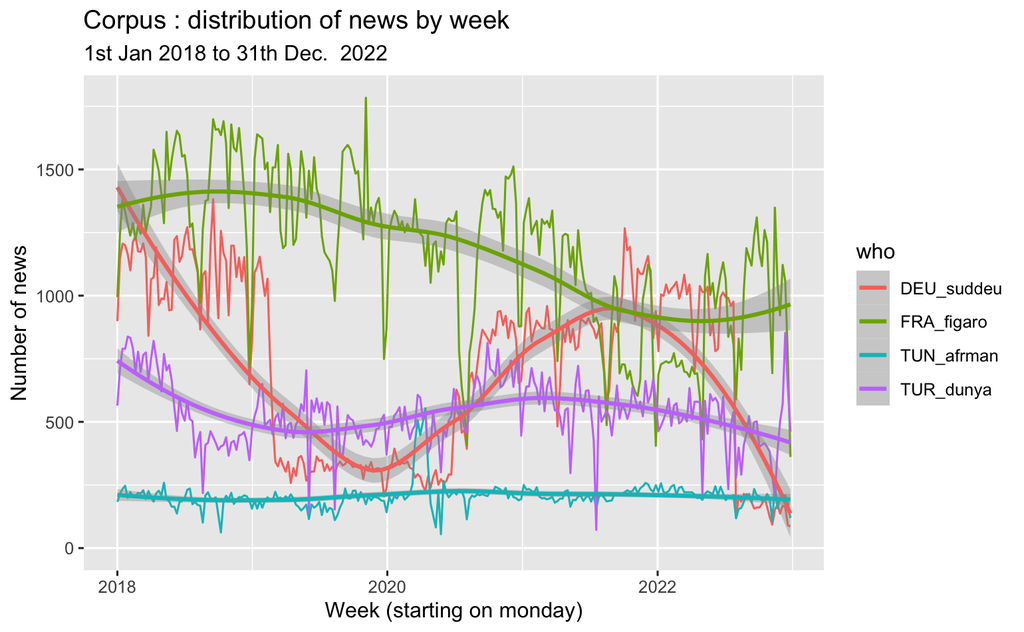

```r
news_weeks<-dt[,.(newstot=.N),by=.(week,who)]

p<-ggplot(news_weeks, aes(x=as.Date(week),y=newstot, col=who))+
   geom_line()+
   geom_smooth(method = 'loess', formula = 'y~x')+
   scale_y_continuous("Number of news", limits = c(0,NA)) +
   scale_x_date("Week (starting on monday)") +
         ggtitle(label ="Corpus : distribution of news by week",
                  subtitle = "1st Jan 2018 to 31th Dec.  2022")
p
```

### News by weekday

We examine if the distribution is regular by weekday and check in particular the effect of the week-end.

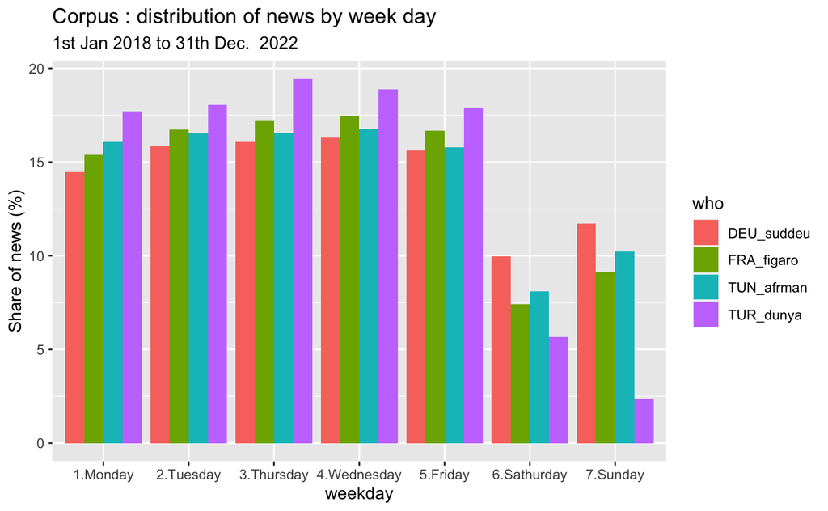

```r
#compute frequencies by weekday
news_weekdays<-dt[,.(newstot=.N),by=.(weekday,who)]
news_weekdays<-news_weekdays[,.(weekday,newspct=100*newstot/sum(newstot)),by=.(who)]


# Translate weekdays in english and order
news_weekdays$weekday<-as.factor(news_weekdays$weekday)
#levels(news_weekdays$weekday)
levels(news_weekdays$weekday)<-c("5.Friday","1.Monday","6.Sathurday","7.Sunday","3.Thursday","2.Tuesday","4.Wednesday")
news_weekdays$weekday<-as.factor(as.character(news_weekdays$weekday))
news_weekdays<-news_weekdays[order(news_weekdays$weekday),]


p<-ggplot(news_weekdays, aes(x=weekday,fill = who, y=newspct))+
         geom_bar(position = "dodge", stat="identity")+
         scale_y_continuous("Share of news (%)", limits = c(0,NA)) +
         ggtitle(label ="Corpus : distribution of news by week day",
                  subtitle = "1st Jan 2018 to 31th Dec.  2022")
p
```

## Transform in quanteda corpus

### Reshape news by sentences

Unfortunately, the division in text is sentences realized by quanteda is far from perfect which is due to problems in the collection of news. For example, the following text will be considered as a single sentence because the point is not followed by a blank character.

> Le conflit est terminé.Mais la Russie est-elle d’accord avec la Turquie.

It is necessary to add a regular expression for the cleaning of text and the inclusion of a blank space ” ” after each point located after a lower case character and before an upper case character :

str_replace_all(txt,“(?<=[:lower:])\.(?=[:upper:])”, “\.”)

In order to obtain a text that will be recognised as made of 2 sentences.

> Le conflit est terminé. Mais la Russie est-elle d’accord avec la Turquie.

Some sentences appears too short or too long for a sound analysis. Therefore, we decide to eliminate outliers based on the quantile of the numbe of tokens. In practice we decide to eliminate the sentences with more than 100 tokens or less than 3 tokensr

```r
#dt<-readRDS("corpus/dt_mycorpus.RDS")

t1<-Sys.time()

# clean sentences break (long !)
dt$text<-str_replace_all(dt$text,"(?<=[:lower:])\\.(?=[:upper:])", "\\. ")


# transform in quanteda
qd<-corpus(dt,docid_field = "id",text_field = "text")



# break in sentences
qd<-corpus_reshape(qd,to="sentences", use_docvars=T)

# Identify rank of sentences
qd$order<-as.numeric(as.data.frame(str_split(names(qd),"\\.", simplify=T))[,2])

# Select only title + maximum of 3 sentences
qd<-corpus_subset(qd, order < 2)

# filter by number of tokens by sentence
qd$nbt<-ntoken(texts(qd))
#mintok<-quantile(qd$nbt,0.01)
#maxtok<-quantile(qd$nbt,0.99)
#qd<-corpus_subset(qd, nbt>mintok)
qd<-corpus_subset(qd, nbt<100)
qd<-corpus_subset(qd, nbt>2)



# Save corpus in qd format
saveRDS(qd,"corpus/qd_mycorpus.RDS")

t2<-Sys.time()
paste("Program executed in ", t2-t1)

head(qd)
summary(qd,3)
```

[output not shown]

### Number of sentences by media

```r
#qd<-readRDS("corpus/qd_mycorpus.RDS")
x<-data.table(docvars(qd))


tab<-x[,.(tot=.N),by=.(who,order)]
tab<-dcast(tab,order~who)
tab$order<-as.factor(tab$order)
levels(tab$order)<-c("Title","Sent1","Sent2","Sent3")
kable(tab, caption = "Distribution of title and sentences by media")
```

Distribution of title and sentences by media

| order | DEU_suddeu | FRA_figaro | TUN_afrman | TUR_dunya |
| --- | --- | --- | --- | --- |
| Title | 181869 | 305544 | 53182 | 138112 |

### Size of texts by month

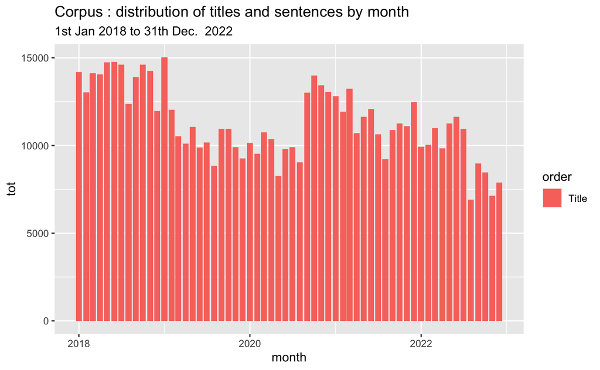

```r
tab<-x[,.(tot=.N),by=.(month,order)]
tab$month<-as.Date(tab$month)
tab$order<-as.factor(tab$order)
levels(tab$order)<-c("Title","Sent1","Sent2","Sent3")


       p<-ggplot(tab, aes(x=month,fill = order, y=tot))+
         geom_bar(stat="identity")+
         ggtitle(label ="Corpus : distribution of titles and sentences by month",
                  subtitle = "1st Jan 2018 to 31th Dec.  2022")
p
```